# 01 Prove - Assignment

## Objectives

- Impliment cs124 Calendar project using python.

## Introduction

In cs124, the second project as a calendar program. Given a year and a month, the program will display a monthly calendar.

### Description Calendar project from cs124

You will be programming a Python 3 program to display a monthly calendar based on a given month and year from the user.

Here is a screen shot of the program running.

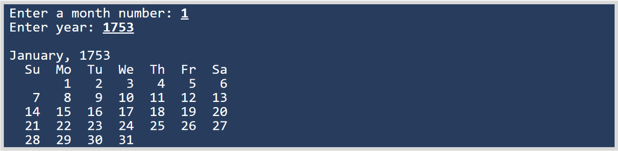

Your program must:

- Only except month values from 1 to 12.
- Only except years from 1753 or later.

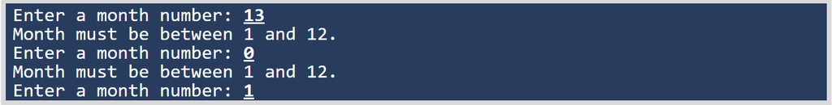

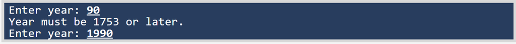

Your program will be counting the number of days from Jan 1st, 1753 to the current month and year given by the user:

- You must create a function called **computeOffset()** that takes in the month and years and returns the offset value outlined below.
- You **must not** use a formula to compute the offset - use loops.
- Take the number of days from 1st Jan 1753 and return that count modulus 7.

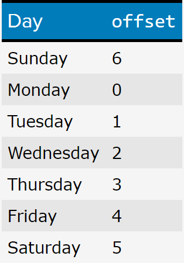

Here is the formatting details of the monthly calendar.

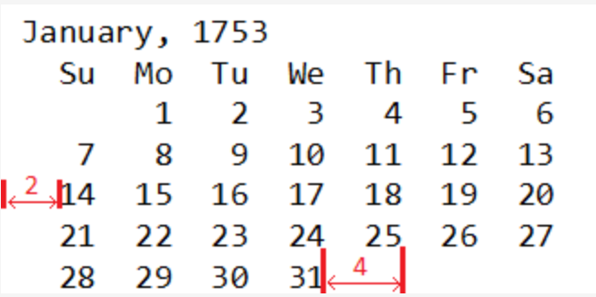

## Assignment

1. Download the project Python file from the GitHub repo. It's in the assignment folder under the `week01` folder.
2. There is no testBed for this assignment. However, make the output match as close as possible.
3. You are **not allowed** to use any Python packages/libraries for this project.
4. This is an individual project - work alone. Don't share code.

Your project must have at least these functions in it (you can have more). The function arguments are not listed here, use what arguments you need. **Global variables are not allowed**.

- compute_offset()
- display()
- is_leap_year()
- get_month()
- get_year()
- number_days_in_month()
- number_days_in_year()

## Rubric

| Task | Points |
| --- | --- |
| Error checking of month and year input | 10 |
| Compute offset using a function using loops | 10 |
| Use of functions | 20 |
| Offset computed correctly | 20 |
| Month displayed correctly | 30 |
| Coding style and presentation (Functions need comments, good variable names, etc...) | 10 |
| ------ | ----- |
| Total | 100 |

## Submission

1. Download the project file from GitHub.
2. Write your code and test it.
3. Upload your Python code to Canvas in the Assignments section for this project.